# earthquake

HImanshu Pareek

August 27, 2017

## Box plot of EARTHQUAKE data

loading data into R. Filename is “EARTHQUAKE.xlsx”

```r
filename <- "EARTHQUAKE.xlsx"

library(readxl)
library(dplyr)
earthquakes <- read_excel(filename, na = c("Not Available", "not available", "NOT AVAILABLE", "na", "NA", "-", "_", "null", "NULL"))
head (earthquakes)
```

```
## # A tibble: 6 x 5
##                  Time Latitude Longitude `Depth/Km` Magnitude
##                <dttm>    <dbl>     <dbl>      <dbl>     <dbl>
## 1 2016-08-24 03:36:32  42.6983   13.2335        8.1       6.0
## 2 2016-08-24 03:37:26  42.7123   13.2533        9.0       4.5
## 3 2016-08-24 03:40:46  42.7647   13.1723        9.7       3.8
## 4 2016-08-24 03:41:38  42.7803   13.1683        9.7       3.9
## 5 2016-08-24 03:42:07  42.7798   13.1575        9.7       3.6
## 6 2016-08-24 03:43:58  42.7298   13.2137       10.7       3.4
```

number of discrepancy is number of rows with na values. This can be calculated by is.na() function

```r
dataOfNAValues <- earthquakes[rowSums(is.na(earthquakes)) > 0,]
head (dataOfNAValues)
```

```
## # A tibble: 0 x 5
## # ... with 5 variables: Time <dttm>, Latitude <dbl>, Longitude <dbl>,
## #   Depth/Km <dbl>, Magnitude <dbl>
```

Here, dataOfNAValues has 0 rows. It means, there is not any discrepancy in our cata. If we somehow forgot to keep names of possible na strings while reading excel file, we have to use omit function to remove all na or not suitable values.

```r
earthquakes <- na.omit(earthquakes)
head (earthquakes)
```

```
## # A tibble: 6 x 5
##                  Time Latitude Longitude `Depth/Km` Magnitude
##                <dttm>    <dbl>     <dbl>      <dbl>     <dbl>
## 1 2016-08-24 03:36:32  42.6983   13.2335        8.1       6.0
## 2 2016-08-24 03:37:26  42.7123   13.2533        9.0       4.5
## 3 2016-08-24 03:40:46  42.7647   13.1723        9.7       3.8
## 4 2016-08-24 03:41:38  42.7803   13.1683        9.7       3.9
## 5 2016-08-24 03:42:07  42.7798   13.1575        9.7       3.6
## 6 2016-08-24 03:43:58  42.7298   13.2137       10.7       3.4
```

We will rename columns to ease of writing

```r
colNames <- c("time", "lat", "long", "depth", "mag")
colnames(earthquakes) <- colNames
head (earthquakes)
```

```
## # A tibble: 6 x 5
##                  time     lat    long depth   mag
##                <dttm>   <dbl>   <dbl> <dbl> <dbl>
## 1 2016-08-24 03:36:32 42.6983 13.2335   8.1   6.0
## 2 2016-08-24 03:37:26 42.7123 13.2533   9.0   4.5
## 3 2016-08-24 03:40:46 42.7647 13.1723   9.7   3.8
## 4 2016-08-24 03:41:38 42.7803 13.1683   9.7   3.9
## 5 2016-08-24 03:42:07 42.7798 13.1575   9.7   3.6
## 6 2016-08-24 03:43:58 42.7298 13.2137  10.7   3.4
```

Subsetting depth and magnitude columns.

```r
new_data <- subset(earthquakes, select = c(depth, mag))
head (new_data)
```

```
## # A tibble: 6 x 2
##   depth   mag
##   <dbl> <dbl>
## 1   8.1   6.0
## 2   9.0   4.5
## 3   9.7   3.8
## 4   9.7   3.9
## 5   9.7   3.6
## 6  10.7   3.4
```

Boxplot before removing outliers

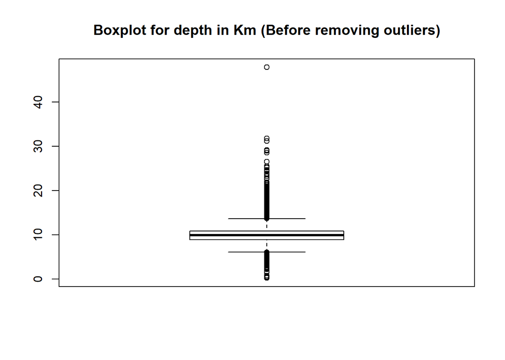

```r
boxplot(new_data$depth, main = "Boxplot for depth in Km (Before removing outliers)")
```

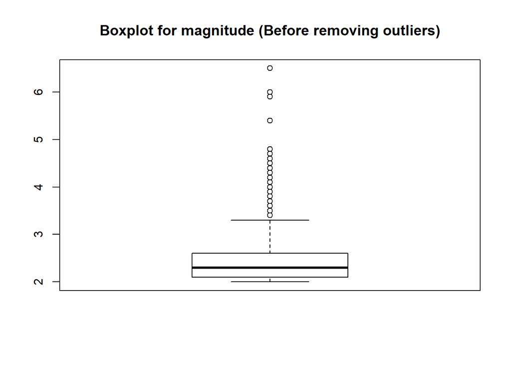

```r
boxplot(new_data$mag, main = "Boxplot for magnitude (Before removing outliers)")
```

Calculating 5 point summary

```r
quantileDepth <- quantile(new_data$depth, probs = c(0, 0.25, 0.50, 0.75, 1.0))
quantileMag <- quantile(new_data$mag, probs = c(0, 0.25, 0.50, 0.75, 1.0))
quantileDepth
```

```
##   0%  25%  50%  75% 100%
##  0.2  8.9  9.9 10.8 47.9
```

```r
quantileMag
```

```
##   0%  25%  50%  75% 100%
##  2.0  2.1  2.3  2.6  6.5
```

Calculating minimum and maximum of depth and magnitude to be used.

```r
q1Depth <- quantileDepth[2]
q3Depth <- quantileDepth[4]
q1Mag <- quantileMag[2]
q3Mag <- quantileMag[4]

IQRDepth <- q3Depth - q1Depth
IQRMag <- q3Mag - q1Mag

minDepth <- q1Depth - (1.5 * IQRDepth)
maxDepth <- q3Depth + (1.5 * IQRDepth)
minMag <- q1Mag - (1.5 * IQRMag)
maxMag <- q3Mag + (1.5 * IQRMag)

sprintf("Range of %s should be %f - %f\n", c("Depth", "Magnitude"), c(minDepth, minMag), c(maxDepth, maxMag))
```

```
## [1] "Range of Depth should be 6.050000 - 13.650000\n"
## [2] "Range of Magnitude should be 1.350000 - 3.350000\n"
```

Now, we will remove data below minimum limit and above maximum limit.

```r
new_data <- filter(new_data, depth >= minDepth & depth <= maxDepth & mag >= minMag & mag <= maxMag)
```

Boxplot after removing outliers

```r
sprintf("After removing outliers")
```

```
## [1] "After removing outliers"
```

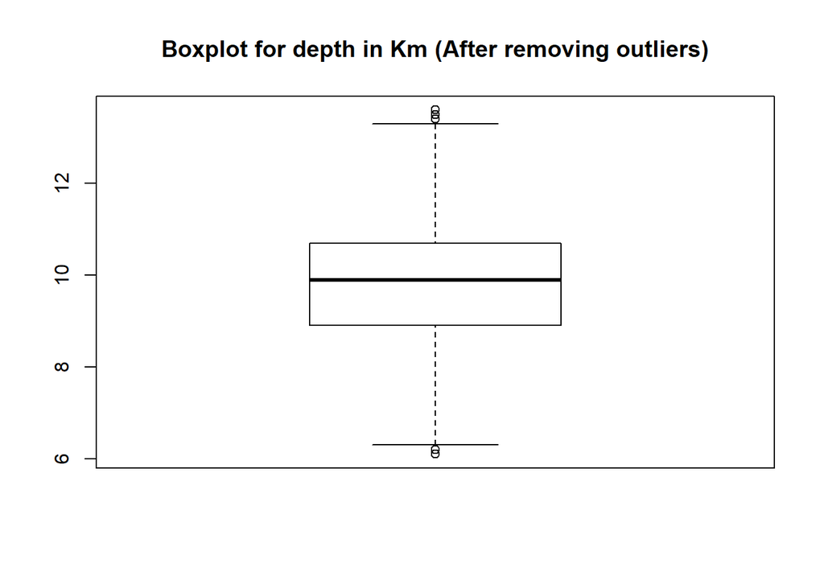

```r
boxplot(new_data$depth, main = "Boxplot for depth in Km (After removing outliers)")
```

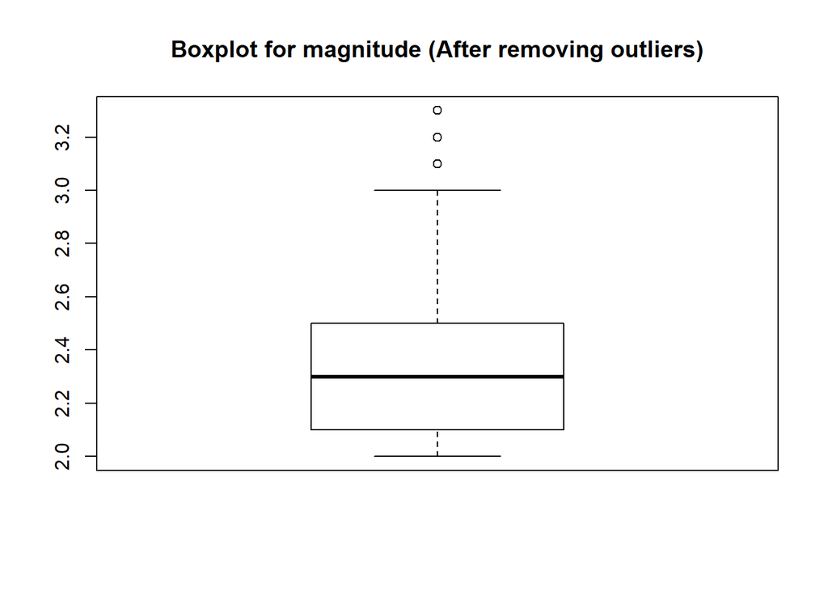

```r
boxplot(new_data$mag, main = "Boxplot for magnitude (After removing outliers)")
```

Calculating 5 point summary

```r
quantileDepth <- quantile(new_data$depth, probs = c(0, 0.25, 0.50, 0.75, 1.0))
quantileMag <- quantile(new_data$mag, probs = c(0, 0.25, 0.50, 0.75, 1.0))
quantileDepth
```

```
##   0%  25%  50%  75% 100%
##  6.1  8.9  9.9 10.7 13.6
```

```r
quantileMag
```

```
##   0%  25%  50%  75% 100%
##  2.0  2.1  2.3  2.5  3.3
```